# 3_3_Indices_Ancestria_tssr3

Idalia Rojas

2025-07-25

## Requerimentos

- tess3
- tydiverse
- devtools
- maps
- LEA
- vcftools
- bcftools
- ADMIXTUEE

Call libraries

```r
library(maps)
library(tess3r)
library(LEA)
library(tidyverse)
setwd(dirname(rstudioapi::getActiveDocumentContext()$path))
getwd()
```

```
## [1] "/home/irojas/git.repositories/Bioinformatics4EvolBio/Curso_CongresoBiolEvolMex/Seccion_III"
```

## Indices de ancestria

Los índices de ancestría son un análisis de agrupamiento no supervisado que emplea el método de K-medias para agrupar genotipos en diferentes grupos. En este tutorial utilizaremos el paquete de R `Tess3`: https://bcm-uga.github.io/TESS3_encho_sen/articles/main-vignette.html

Transformar nuestro archivo en el archivo de genotipos que emplea tss3.

1. Convertir de vcf a archivo plink (map, ped), para ello emplearemos vcftools:
2. Se recomienda partir del formato ped a lfmm

```r
maices.geno <- ped2lfmm(input.file = "./subset/maices_subset.ped", output.file = "./subset/maices_subset.lfmm", force = TRUE)
```

```
##
##  - number of detected individuals:   75
##  - number of detected loci:      295578
```

```r
head(maices.geno)
```

```
## [1] "./subset/maices_subset.lfmm"
```

```r
class(maices.geno)
```

```
## [1] "character"
```

## Generar archivo con las coordenadas

La ejecución de la función principal tess3 requiere dos archivos: 1) un archivo que codifique genotipos individuales, y 2) un archivo con coordenadas geográficas individuales.

Cargaremos los metadatos con las coordenadas y los ordenaremos de acuerdo al orden del archivo vcf

El formato *.geno* difiere del formato vcf, que es equivalente a *Individual_Individual*. El orden del archivo plink se empleo para ordenar los metadatos. La longitud (°E) y la latitud (°N) deben codificarse en formato decimal sin enbezados.

```r
order_geno <- as.vector(sorted.IDs$Individual)

coordenadas <- read.delim("./meta/maices_subset_metadata.txt", head = TRUE, sep = "\t")
coordenadas <- coordenadas[match(order_geno, coordenadas$Genotipo),]
coordenadas$geno_format <- paste(sorted.IDs$Individual, sorted.IDs$Individual, sep = "_" )

geno_coordenadas <- coordenadas[, c("Longitude", "Latitude")]
colnames(geno_coordenadas) <- NULL
geno_coordenadas <- as.matrix(geno_coordenadas)
```

```r
genotypes <- read.lfmm("./subset/maices_subset.lfmm")
dim(genotypes)
```

```
## [1]     75 295578
```

```r
genotypes[genotypes > 2] <- NA

tess3.obj <- tess3(X = genotypes, coord = geno_coordenadas, K = 1:10,
                   method = "projected.ls", ploidy = 2, openMP.core.num = 4)
```

[output not shown]

Plot ancestry values

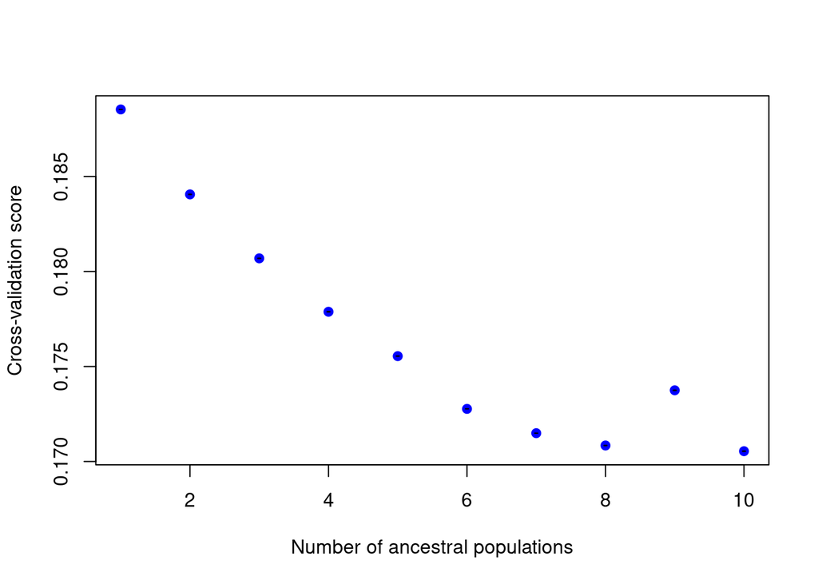

```r
plot(tess3.obj, pch = 19, col = "blue",
     xlab = "Number of ancestral populations",
     ylab = "Cross-validation score")
```

```r
q.matrix <- qmatrix(tess3.obj, K = 4)
row.names(q.matrix) <- sorted.IDs$Individual
# STRUCTURE-like barplot for the Q-matrix
barplot(q.matrix, border = NA, space = 0,
        xlab = "Individuals", ylab = "Ancestry proportions",
        main = "Ancestry matrix") -> bp
```

```
## Use CreatePalette() to define color palettes.
```

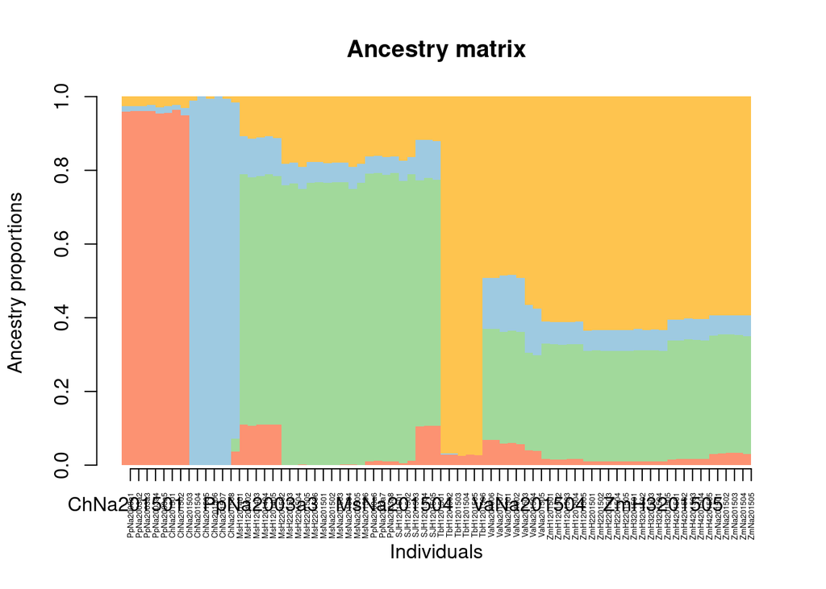

```r
axis(1, at = 1:nrow(q.matrix), labels = sorted.IDs$Individual, las = 3, cex.axis = .4)
```

Graficar el mapa

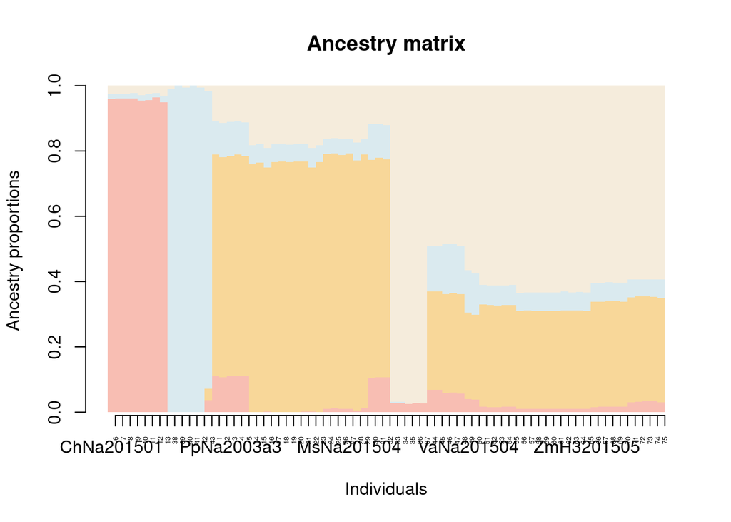

```r
my.colors <- c("tomato", "orange", "lightblue", "wheat","olivedrab")
my.palette <- CreatePalette(my.colors, 9)
barplot(q.matrix, border = NA, space = 0,
        main = "Ancestry matrix",
        xlab = "Individuals", ylab = "Ancestry proportions",
        col.palette = my.palette) -> bp
axis(1, at = 1:nrow(q.matrix), labels = bp$order, las = 3, cex.axis = .4)
```

```
## This function required to attach maps namespace.
```

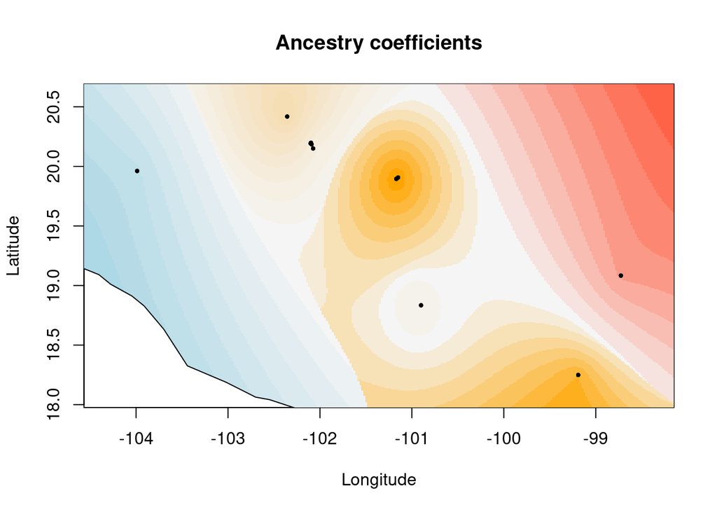

```r
###

plot(q.matrix,  geno_coordenadas, method = "map.max", interpol = FieldsKrigModel(10),
     main = "Ancestry coefficients",
     xlab = "Longitude", ylab = "Latitude",
     resolution = c(300,300), cex = .4,
     col.palette = my.palette)
```